# Outline

#### 1. Introduction

```
 1.1. Brief explanation of the Dataset
 1.2. Summary of tools or libraries needed for the exploration
```

#### 2. Data Wrangling

```
 2.1. Import of needed libraries
 2.2. Data Understanding
 2.3. Accessing Data for errors & Irregularities
 2.4. Cleaning the Errors from the Data
```

#### 3. Data Exploration

```
 3.1. Univariate Analysis & Visualizations
 3.2. Bivariate Analysis & Visualizations
 3.3. Multivariate Analysis & Visualizations
```

# 1. Introduction

```
This notebook reflects the analysis done for the project three (3), a requirement for the Udacity-Data Analyst Program. This project is aimed at solidfying the knowledge gained during the Data Exploratory & Explanatory lectures offered in the classroom. Thus, this notebook will involve the exploration and visualization of a dataset to be discussed below.
```

### 1.1. Brief Explanation of the Dataset.

```
There are several datasets provided to complete this project. I will be working with the Ford GoBike System Data. This data set includes information about individual rides made in a bike-sharing system covering the greater San Francisco Bay area.
```

[figure not shown]

### 1.2. Summary of Tools/ Libraries needed for the Exploration

```
In this project, the major tool/libraries needed include the following:
```

- Pandas: This is a python library which handles data manipulation and data wrangling. It helps to view data in DataFrames & Series. It could be used for simple/quick viusualizations
- NumPy: NumPy is a Numerical Python library, used for dealing with data in arrays and several dimensions
- Matplotlib: Matplotlib is a python library used basically for visualization of data.
- Seaborn: Seaborn is used for a more interactive visualizations, and for beautifying visualizations.

# 2. Data Wrangling

This section cuts across, the import of needed libraries, data understanding, accessing the dataset, & cleaning the data

### 2.1. Import of Needed Libraries

```python
import pandas as pd
import numpy as np
import matplotlib.pyplot as plt
import seaborn as sns

%matplotlib inline
```

### 2.2. Data Understanding

```python
# Let's load the dataset into pandas DataFrame
bike_data = pd.read_csv('201902-fordgobike-tripdata.csv')

# view first five rows of the dataset
bike_data.head()
```

|  | duration_sec | start_time | end_time | start_station_id | start_station_name | start_station_latitude | start_station_longitude | end_station_id | end_station_name | end_station_latitude | end_station_longitude | bike_id | user_type | member_birth_year | member_gender | bike_share_for_all_trip |
| --- | --- | --- | --- | --- | --- | --- | --- | --- | --- | --- | --- | --- | --- | --- | --- | --- |
| 0 | 52185 | 2019-02-28 17:32:10.1450 | 2019-03-01 08:01:55.9750 | 21.0 | Montgomery St BART Station (Market St at 2nd St) | 37.789625 | -122.400811 | 13.0 | Commercial St at Montgomery St | 37.794231 | -122.402923 | 4902 | Customer | 1984.0 | Male | No |
| 1 | 42521 | 2019-02-28 18:53:21.7890 | 2019-03-01 06:42:03.0560 | 23.0 | The Embarcadero at Steuart St | 37.791464 | -122.391034 | 81.0 | Berry St at 4th St | 37.775880 | -122.393170 | 2535 | Customer | NaN | NaN | No |
| 2 | 61854 | 2019-02-28 12:13:13.2180 | 2019-03-01 05:24:08.1460 | 86.0 | Market St at Dolores St | 37.769305 | -122.426826 | 3.0 | Powell St BART Station (Market St at 4th St) | 37.786375 | -122.404904 | 5905 | Customer | 1972.0 | Male | No |
| 3 | 36490 | 2019-02-28 17:54:26.0100 | 2019-03-01 04:02:36.8420 | 375.0 | Grove St at Masonic Ave | 37.774836 | -122.446546 | 70.0 | Central Ave at Fell St | 37.773311 | -122.444293 | 6638 | Subscriber | 1989.0 | Other | No |
| 4 | 1585 | 2019-02-28 23:54:18.5490 | 2019-03-01 00:20:44.0740 | 7.0 | Frank H Ogawa Plaza | 37.804562 | -122.271738 | 222.0 | 10th Ave at E 15th St | 37.792714 | -122.248780 | 4898 | Subscriber | 1974.0 | Male | Yes |

```python
# View last five rows of the dataset
bike_data.tail()
```

|  | duration_sec | start_time | end_time | start_station_id | start_station_name | start_station_latitude | start_station_longitude | end_station_id | end_station_name | end_station_latitude | end_station_longitude | bike_id | user_type | member_birth_year | member_gender | bike_share_for_all_trip |
| --- | --- | --- | --- | --- | --- | --- | --- | --- | --- | --- | --- | --- | --- | --- | --- | --- |
| 183407 | 480 | 2019-02-01 00:04:49.7240 | 2019-02-01 00:12:50.0340 | 27.0 | Beale St at Harrison St | 37.788059 | -122.391865 | 324.0 | Union Square (Powell St at Post St) | 37.788300 | -122.408531 | 4832 | Subscriber | 1996.0 | Male | No |
| 183408 | 313 | 2019-02-01 00:05:34.7440 | 2019-02-01 00:10:48.5020 | 21.0 | Montgomery St BART Station (Market St at 2nd St) | 37.789625 | -122.400811 | 66.0 | 3rd St at Townsend St | 37.778742 | -122.392741 | 4960 | Subscriber | 1984.0 | Male | No |
| 183409 | 141 | 2019-02-01 00:06:05.5490 | 2019-02-01 00:08:27.2200 | 278.0 | The Alameda at Bush St | 37.331932 | -121.904888 | 277.0 | Morrison Ave at Julian St | 37.333658 | -121.908586 | 3824 | Subscriber | 1990.0 | Male | Yes |
| 183410 | 139 | 2019-02-01 00:05:34.3600 | 2019-02-01 00:07:54.2870 | 220.0 | San Pablo Ave at MLK Jr Way | 37.811351 | -122.273422 | 216.0 | San Pablo Ave at 27th St | 37.817827 | -122.275698 | 5095 | Subscriber | 1988.0 | Male | No |
| 183411 | 271 | 2019-02-01 00:00:20.6360 | 2019-02-01 00:04:52.0580 | 24.0 | Spear St at Folsom St | 37.789677 | -122.390428 | 37.0 | 2nd St at Folsom St | 37.785000 | -122.395936 | 1057 | Subscriber | 1989.0 | Male | No |

```python
# Information about the dataset
bike_data.info()
```

```
<class 'pandas.core.frame.DataFrame'>
RangeIndex: 183412 entries, 0 to 183411
Data columns (total 16 columns):
duration_sec               183412 non-null int64
start_time                 183412 non-null object
end_time                   183412 non-null object
start_station_id           183215 non-null float64
start_station_name         183215 non-null object
start_station_latitude     183412 non-null float64
start_station_longitude    183412 non-null float64
end_station_id             183215 non-null float64
end_station_name           183215 non-null object
end_station_latitude       183412 non-null float64
end_station_longitude      183412 non-null float64
bike_id                    183412 non-null int64
user_type                  183412 non-null object
member_birth_year          175147 non-null float64
member_gender              175147 non-null object
bike_share_for_all_trip    183412 non-null object
dtypes: float64(7), int64(2), object(7)
memory usage: 22.4+ MB
```

```python
# Statistical Summary of the Dataset
bike_data.describe()
```

|  | duration_sec | start_station_id | start_station_latitude | start_station_longitude | end_station_id | end_station_latitude | end_station_longitude | bike_id | member_birth_year |
| --- | --- | --- | --- | --- | --- | --- | --- | --- | --- |
| count | 183412.000000 | 183215.000000 | 183412.000000 | 183412.000000 | 183215.000000 | 183412.000000 | 183412.000000 | 183412.000000 | 175147.000000 |
| mean | 726.078435 | 138.590427 | 37.771223 | -122.352664 | 136.249123 | 37.771427 | -122.352250 | 4472.906375 | 1984.806437 |
| std | 1794.389780 | 111.778864 | 0.099581 | 0.117097 | 111.515131 | 0.099490 | 0.116673 | 1664.383394 | 10.116689 |
| min | 61.000000 | 3.000000 | 37.317298 | -122.453704 | 3.000000 | 37.317298 | -122.453704 | 11.000000 | 1878.000000 |
| 25% | 325.000000 | 47.000000 | 37.770083 | -122.412408 | 44.000000 | 37.770407 | -122.411726 | 3777.000000 | 1980.000000 |
| 50% | 514.000000 | 104.000000 | 37.780760 | -122.398285 | 100.000000 | 37.781010 | -122.398279 | 4958.000000 | 1987.000000 |
| 75% | 796.000000 | 239.000000 | 37.797280 | -122.286533 | 235.000000 | 37.797320 | -122.288045 | 5502.000000 | 1992.000000 |
| max | 85444.000000 | 398.000000 | 37.880222 | -121.874119 | 398.000000 | 37.880222 | -121.874119 | 6645.000000 | 2001.000000 |

### 2.3. Accessing Data for Errors/Iregularities

```python
bike_data.isna().sum()
```

```
duration_sec                  0
start_time                    0
end_time                      0
start_station_id            197
start_station_name          197
start_station_latitude        0
start_station_longitude       0
end_station_id              197
end_station_name            197
end_station_latitude          0
end_station_longitude         0
bike_id                       0
user_type                     0
member_birth_year          8265
member_gender              8265
bike_share_for_all_trip       0
dtype: int64
```

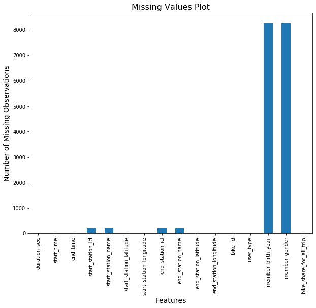

```python
sb = sns.color_palette()[0]
plt.figure(figsize=(10, 8))
bike_data.isna().sum().plot(kind='bar', color=sb)
plt.title('Missing Values Plot', fontsize=16)
plt.ylabel('Number of Missing Observations', fontsize=14)
plt.xlabel('Features', fontsize=14);
```

#### Observations

1. start_time & end_time have date & time together, which is not a good fit for data entry.
2. Missing values in columns like; start_station_name, start_station_name, end_station_id, end_station_name, member_birth_year, member_gender.
3. The member_birth_year, start_station_id and end_station_id should be integers as well

PS: Separation of the date & time will aid the accurate calculation of the durations in seconds

### 2.4. Cleaning the Errors from the Data

```python
# Making a copy of the dataset

bike_data_clean = bike_data.copy()
```

I. start_time & end_time have date & time together, which is not a good fit for data entry.

#### Define

Extraction of time from date in the start_time & end_time columns

#### Code

```python
# Let's define a functions for the Operation
def extract_time(time, col):
    # code for extraction of time
    bike_data_clean[time] = pd.to_datetime(bike_data_clean[col]).dt.time

def extract_date(date, col):
    # code for extraction of date
    bike_data_clean[date] = pd.to_datetime(bike_data_clean[col]).dt.date
```

```python
# Extracting the time
extract_time('Start_time', 'start_time')
extract_time('End_time', 'end_time')
```

```python
# Extracting the date
extract_date('Start_date', 'start_time')
extract_date('End_date', 'end_time')
```

```python
# Let's drop the start_time & end_time columns as they may not be useful anymore
bike_data_clean = bike_data_clean.drop(columns=['start_time', 'end_time'])
```

### Test

```python
bike_data_clean.head()
```

|  | duration_sec | start_station_id | start_station_name | start_station_latitude | start_station_longitude | end_station_id | end_station_name | end_station_latitude | end_station_longitude | bike_id | user_type | member_birth_year | member_gender | bike_share_for_all_trip | Start_time | End_time | Start_date | End_date |
| --- | --- | --- | --- | --- | --- | --- | --- | --- | --- | --- | --- | --- | --- | --- | --- | --- | --- | --- |
| 0 | 52185 | 21.0 | Montgomery St BART Station (Market St at 2nd St) | 37.789625 | -122.400811 | 13.0 | Commercial St at Montgomery St | 37.794231 | -122.402923 | 4902 | Customer | 1984.0 | Male | No | 17:32:10.145000 | 08:01:55.975000 | 2019-02-28 | 2019-03-01 |
| 1 | 42521 | 23.0 | The Embarcadero at Steuart St | 37.791464 | -122.391034 | 81.0 | Berry St at 4th St | 37.775880 | -122.393170 | 2535 | Customer | NaN | NaN | No | 18:53:21.789000 | 06:42:03.056000 | 2019-02-28 | 2019-03-01 |
| 2 | 61854 | 86.0 | Market St at Dolores St | 37.769305 | -122.426826 | 3.0 | Powell St BART Station (Market St at 4th St) | 37.786375 | -122.404904 | 5905 | Customer | 1972.0 | Male | No | 12:13:13.218000 | 05:24:08.146000 | 2019-02-28 | 2019-03-01 |
| 3 | 36490 | 375.0 | Grove St at Masonic Ave | 37.774836 | -122.446546 | 70.0 | Central Ave at Fell St | 37.773311 | -122.444293 | 6638 | Subscriber | 1989.0 | Other | No | 17:54:26.010000 | 04:02:36.842000 | 2019-02-28 | 2019-03-01 |
| 4 | 1585 | 7.0 | Frank H Ogawa Plaza | 37.804562 | -122.271738 | 222.0 | 10th Ave at E 15th St | 37.792714 | -122.248780 | 4898 | Subscriber | 1974.0 | Male | Yes | 23:54:18.549000 | 00:20:44.074000 | 2019-02-28 | 2019-03-01 |

II. Missing values in columns like; start_station_name, start_station_name, end_station_id, end_station_name, member_birth_year, member_gender

#### Define

- Missing values are very negligible compared to the entire dataset
- Dropping of the missing values

#### Code

```python
# Let's drop all the missing values in the dataset
bike_data_clean = bike_data_clean.dropna()
```

### Test

```python
bike_data_clean.isna().sum()
```

```
duration_sec               0
start_station_id           0
start_station_name         0
start_station_latitude     0
start_station_longitude    0
end_station_id             0
end_station_name           0
end_station_latitude       0
end_station_longitude      0
bike_id                    0
user_type                  0
member_birth_year          0
member_gender              0
bike_share_for_all_trip    0
Start_time                 0
End_time                   0
Start_date                 0
End_date                   0
dtype: int64
```

```python
bike_data_clean.shape
```

```
(174952, 18)
```

III. The member_birth_year, start_station_id and end_station_id should be integers as well

#### Define

- Changing the datatype from floats to integers

#### Code

```python
# Let's define a function to handle this operation
def change_datatype(col):
    bike_data_clean[col] = bike_data_clean[col].astype(int)
```

```python
change_datatype('member_birth_year')
change_datatype('start_station_id')
change_datatype('end_station_id')
```

#### Test

```python
bike_data_clean.info()
```

```
<class 'pandas.core.frame.DataFrame'>
Int64Index: 174952 entries, 0 to 183411
Data columns (total 18 columns):
duration_sec               174952 non-null int64
start_station_id           174952 non-null int32
start_station_name         174952 non-null object
start_station_latitude     174952 non-null float64
start_station_longitude    174952 non-null float64
end_station_id             174952 non-null int32
end_station_name           174952 non-null object
end_station_latitude       174952 non-null float64
end_station_longitude      174952 non-null float64
bike_id                    174952 non-null int64
user_type                  174952 non-null object
member_birth_year          174952 non-null int32
member_gender              174952 non-null object
bike_share_for_all_trip    174952 non-null object
Start_time                 174952 non-null object
End_time                   174952 non-null object
Start_date                 174952 non-null object
End_date                   174952 non-null object
dtypes: float64(4), int32(3), int64(2), object(9)
memory usage: 23.4+ MB
```

# 3. Data Exploration

### 3.1. Univariate Analysis & Visualizations

#### i. Let's visualize to see ratio of members gender in distribution in the dataset

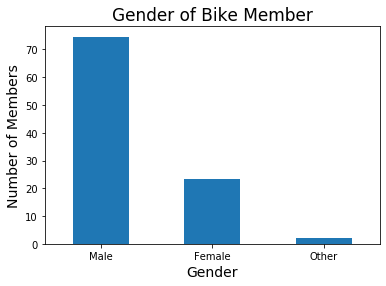

```python
# Let's take into consideration the gender of the member
#sb = sns.color_palette()[0]
bike_data_clean['member_gender'].value_counts(normalize=True).mul(100).plot(kind='bar', rot=0)
plt.title('Gender of Bike Member', fontsize=17)
plt.ylabel('Number of Members', fontsize=14)
plt.xlabel('Gender', fontsize=14);
```

Let's try to visualize this plot base on percentage

```python
# calculating the percentage of the gender of the members involved
total_member = bike_data_clean['member_gender'].value_counts().sum()
male_percentage = round((bike_data_clean['member_gender'].value_counts()[0]/ total_member) * 100, 2)
female_percentage = round((bike_data_clean['member_gender'].value_counts()[1]/ total_member) * 100, 2)
others_percentage = round((bike_data_clean['member_gender'].value_counts()[2]/ total_member) * 100, 2)
```

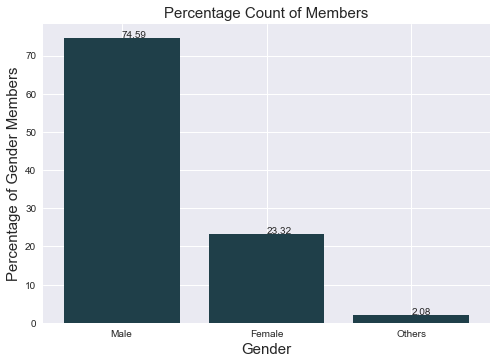

```python
# Let's define a list for the gender
plt.style.use('seaborn')
gender = ['Male', 'Female', 'Others']
# Let's define a list for the percentage of the gender
gender_percentage = [male_percentage, female_percentage, others_percentage]

n = 3
r = np.arange(n)
plt.bar(r, gender_percentage, color='#1F3F49')

plt.xlabel('Gender', fontsize=15)
plt.ylabel('Percentage of Gender Members', fontsize=15)
plt.title('Percentage Count of Members', fontsize=15)
plt.xticks(r, gender)
#plt.yaxis.set_axis(False)
for i in range(len(r)):
    plt.text(i, gender_percentage[i], gender_percentage[i])
```

#### ii. Let's observe the density of members birth year from the dataset

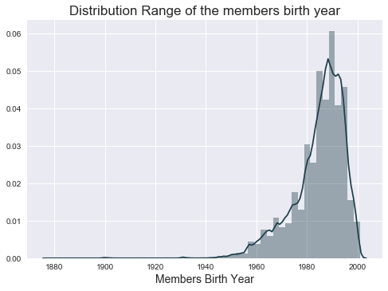

```python
sns.distplot(bike_data_clean['member_birth_year'], color='#1F3F49')
plt.title('Distribution Range of the members birth year', fontsize=17)
plt.xlabel('Members Birth Year', fontsize=14);
```

#### Observation

- From the distribution plot above it can be observed that the major population of the bike members are found between 1960 to 2000

#### iii. Percentage of the User Type in the Bike System.

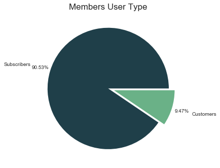

```python
colors = ['#1F3F49', '#6AB187']
explode = (0, 0.1)
plt.pie(bike_data_clean['user_type'].value_counts(), labels=['Subscribers', 'Customers'], autopct= '%1.2f%%',
        colors=colors, explode=explode, pctdistance=1.17, labeldistance=1.34)
plt.title('Members User Type', fontsize=17);
```

#### Observation

From the plot above the followings are observed;

- 90.53% of the users are Subscribers
- 9.47% of the users are customers

Thus, decision making and improvement done should always consider the subscribers as they are the major users of the bike systems

#### iv. Let's observe the ratio of bike shared for all the trip

```python
bike_data_clean.columns
```

```
Index(['duration_sec', 'start_station_id', 'start_station_name',
       'start_station_latitude', 'start_station_longitude', 'end_station_id',
       'end_station_name', 'end_station_latitude', 'end_station_longitude',
       'bike_id', 'user_type', 'member_birth_year', 'member_gender',
       'bike_share_for_all_trip', 'Start_time', 'End_time', 'Start_date',
       'End_date'],
      dtype='object')
```

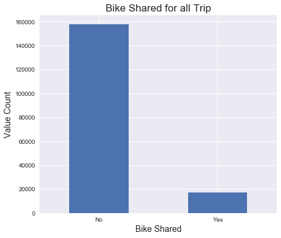

```python
plt.figure(figsize=(7, 6))
bike_data_clean['bike_share_for_all_trip'].value_counts().plot(kind='bar', rot=0)
plt.title('Bike Shared for all Trip', fontsize=17)
plt.xlabel('Bike Shared', fontsize=14)
plt.ylabel('Value Count', fontsize=14);
```

```python
total_bike = bike_data_clean['bike_share_for_all_trip'].value_counts().sum()
bike_no = round((bike_data_clean['bike_share_for_all_trip'].value_counts()[0]/total_bike)*100, 2)
bike_yes = round((bike_data_clean['bike_share_for_all_trip'].value_counts()[1]/total_bike)*100, 2)
```

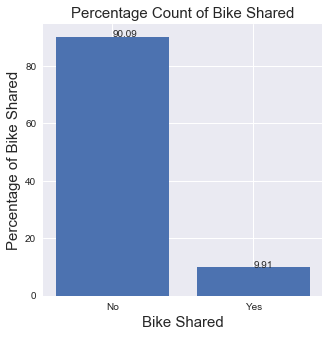

```python
bike_shared = ['No', 'Yes']
# Let's define a list for the percentage of the gender
bike_shared_percentage = [bike_no, bike_yes]

n = 2
r = np.arange(n)
plt.figure(figsize=(5, 5))
plt.bar(r, bike_shared_percentage)

plt.xlabel('Bike Shared', fontsize=15)
plt.ylabel('Percentage of Bike Shared', fontsize=15)
plt.title('Percentage Count of Bike Shared', fontsize=15)
plt.xticks(r, bike_shared)
#plt.yaxis.set_axis(False)
for i in range(len(r)):
    plt.text(i, bike_shared_percentage[i], bike_shared_percentage[i])
```

#### Observation

- From the plot, we discovered that, 9.91% of the bikes where shared for all the trip. while 90.09% of the bikes where not shared.
- Thus, it can be infered that majority of the bikes where only used by one user

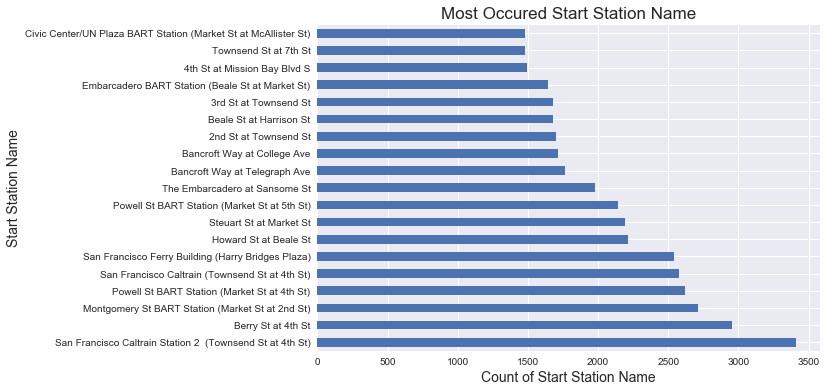

```python
colors = sns.color_palette()[0]
plt.figure(figsize=(9, 6))
bike_data_clean['start_station_name'].value_counts()[1:20].plot(kind='barh', color=colors)
plt.title('Most Occured Start Station Name', fontsize=17)
plt.xlabel('Count of Start Station Name', fontsize=14)
plt.ylabel('Start Station Name', fontsize=14);
```

#### Observation

- This Plot shows the station name frequency of the the start station name.

### 3.2. Bivariate Analysis & Visualizations

#### i. Let's Visualize to see the distance difference between the start latitude and the end latitude.

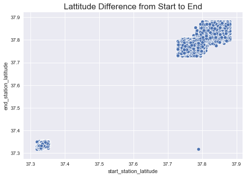

```python
# colors = [sns.color_palette()[0], sns.color_palette()[1]]
sns.scatterplot(data=bike_data_clean, x='start_station_latitude', y='end_station_latitude')
plt.title('Lattitude Difference from Start to End', fontsize=17);
```

#### Observation

- From the plot it is observed that the start latitude is as far as the end latitude, but for a start latitude which deviates from the trend with the end latitude at a low point.
- It can also be inferred that the bikes which too off from a farther latitude also ended at farther latitudes as well.

#### ii. Let's see the longitudinal plot of biking systems

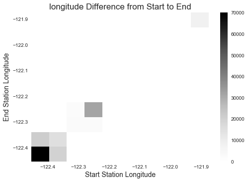

```python
# colors = [sns.color_palette()[0], sns.color_palette()[1]]
plt.style.use('seaborn')
plt.hist2d(data=bike_data_clean, x='start_station_longitude', y='end_station_longitude', )
plt.title('longitude Difference from Start to End', fontsize=17)
plt.xlabel('Start Station Longitude', fontsize=14)
plt.ylabel('End Station Longitude', fontsize=14)
plt.colorbar();
```

#### iii. Let's observe the user type with respect to the member gender

```python
bike_data_clean.sample(3)
```

|  | duration_sec | start_station_id | start_station_name | start_station_latitude | start_station_longitude | end_station_id | end_station_name | end_station_latitude | end_station_longitude | bike_id | user_type | member_birth_year | member_gender | bike_share_for_all_trip | Start_time | End_time | Start_date | End_date |
| --- | --- | --- | --- | --- | --- | --- | --- | --- | --- | --- | --- | --- | --- | --- | --- | --- | --- | --- |
| 37833 | 856 | 49 | S Park St at 3rd St | 37.780760 | -122.394989 | 355 | 23rd St at Tennessee St | 37.755367 | -122.388795 | 4812 | Subscriber | 1995 | Male | No | 13:11:17.240000 | 13:25:33.363000 | 2019-02-23 | 2019-02-23 |
| 25513 | 913 | 36 | Folsom St at 3rd St | 37.783830 | -122.398870 | 343 | Bryant St at 2nd St | 37.783172 | -122.393572 | 4455 | Subscriber | 1988 | Male | No | 16:42:17.828000 | 16:57:30.938000 | 2019-02-25 | 2019-02-25 |
| 129024 | 377 | 280 | San Fernando St at 7th St | 37.337122 | -121.883215 | 296 | 5th St at Virginia St | 37.325998 | -121.877120 | 3869 | Subscriber | 1996 | Male | Yes | 11:47:10.866000 | 11:53:28.253000 | 2019-02-10 | 2019-02-10 |

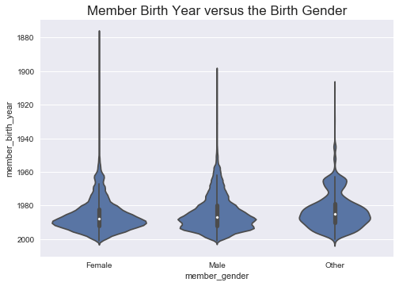

```python
# Let's sort get the order for the membership gender
gender_class = ['Female', 'Male', 'Other']
gender = pd.api.types.CategoricalDtype(ordered=True, categories=gender_class)

# Apply the transform to the column
bike_data_clean['member_gender'] = bike_data_clean['member_gender'].astype(gender)

base_colors = sns.color_palette()[0]
sns.violinplot(data=bike_data_clean, x='member_gender', y='member_birth_year', color=base_colors)
plt.title('Member Birth Year versus the Birth Gender', fontsize=17)
plt.gca().invert_yaxis();
```

#### iv. Let's observe the birth year of user types

```python
bike_data_clean['user_type'].value_counts()
```

```
Subscriber    158386
Customer       16566
Name: user_type, dtype: int64
```

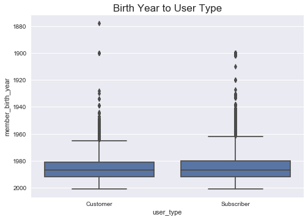

```python
sns.boxplot(data=bike_data_clean, x='user_type', y='member_birth_year', color=base_colors)
plt.title('Birth Year to User Type', fontsize=17)
plt.gca().invert_yaxis();
```

#### Observation

This plot shows the presence of outliers in the dataset. But my interest is in the number of spread of the birth year of the members with respect to the user type

#### v. Let's Check which user types by their gender

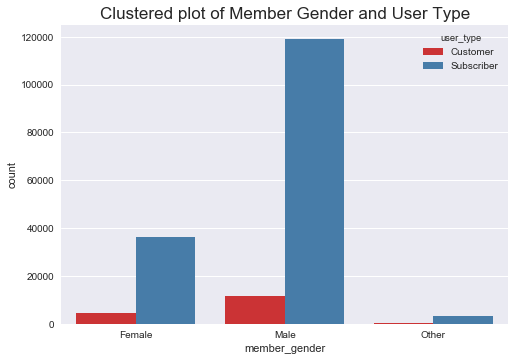

```python
sns.countplot(data=bike_data_clean, x='member_gender', hue='user_type', palette='Set1')
plt.title('Clustered plot of Member Gender and User Type', fontsize=17);
```

#### Observations

- We have more of the male gender in the biking system.
- We have more of the Subscribers in the biking system than the Customers User type.

#### vi. Let's see the trend of the birth year to gender

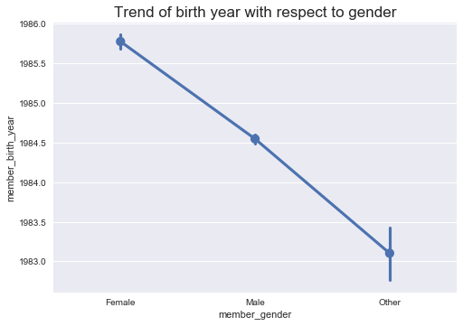

```python
sns.pointplot(data=bike_data_clean, x='member_gender', y='member_birth_year')
plt.title('Trend of birth year with respect to gender', fontsize=17);
```

#### Observation

From the plot above,

- The downward trend shows the decline in average birth year of the biking members

#### vii. Let's observe the spread of bike shared for all trip.

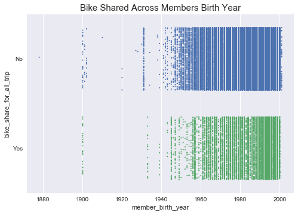

```python
sns.stripplot(data=bike_data_clean, y='bike_share_for_all_trip', x='member_birth_year', orient='h', jitter=0.35, size=2)
plt.title('Bike Shared Across Members Birth Year', fontsize=15);
```

#### Observation

- From the plot above, it is observed that the 'No' bike shared for the trip have members with birth year from 1880 - 2000+. While the 'Yes' bike shared for the trip have members from 1900 to 2000.
- The 'No' bike shared trip for the trip have its members shared across the range, while the 'Yes' bike shared is focused at selected birth years

### 3.3. Multivariate Analysis & Visualizations

#### i. Let's Visualize the bike id relationship to the duration with respect to the birth year of the members

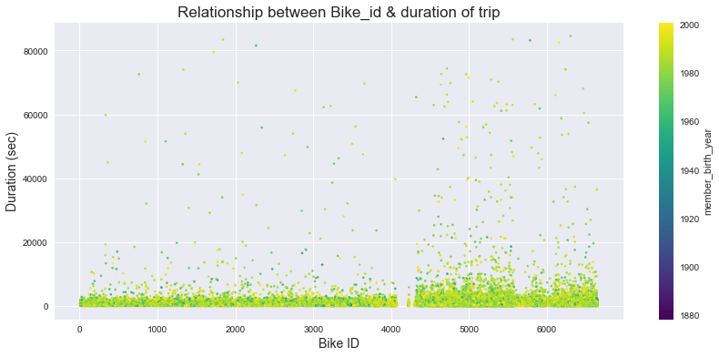

```python
plt.figure(figsize=(14, 6))
plt.scatter(data=bike_data_clean, x='bike_id', y='duration_sec', c='member_birth_year', cmap = 'viridis', s=5)
plt.colorbar(label='member_birth_year')
plt.title('Relationship between Bike_id & duration of trip', fontsize=17)
plt.ylabel('Duration (sec)', fontsize=14)
plt.xlabel('Bike ID', fontsize=14);
```

#### Observation

- From the plot we infer that it took lesser time for most of the bikes to complete the trip
- Members with higher birth rate dominated the trip.

#### ii. Let's visualize the member gender with respect to the user type

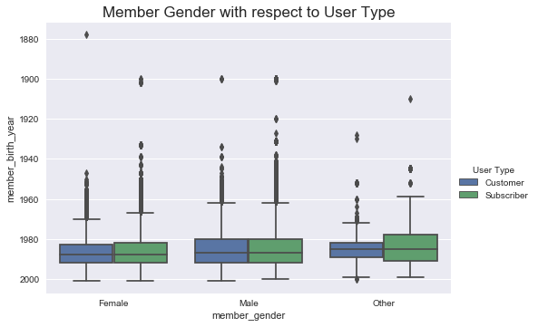

```python
sns.boxplot(data=bike_data_clean, x='member_gender', y='member_birth_year', hue='user_type')
plt.legend(title = 'User Type', loc = 'best', bbox_to_anchor = (1.0, 0.5))
plt.title('Member Gender with respect to User Type', fontsize=17)
plt.gca().invert_yaxis();
```

#### Observation

- The plot shows the presence of outliers cross each gender
- The Female gender has a customer user type with birth year 1880

#### iii. Visualization of the member birth year and duration of ride with respect to the member gender

```python
bike_data_clean.columns
```

```
Index(['duration_sec', 'start_station_id', 'start_station_name',
       'start_station_latitude', 'start_station_longitude', 'end_station_id',
       'end_station_name', 'end_station_latitude', 'end_station_longitude',
       'bike_id', 'user_type', 'member_birth_year', 'member_gender',
       'bike_share_for_all_trip', 'Start_time', 'End_time', 'Start_date',
       'End_date'],
      dtype='object')
```

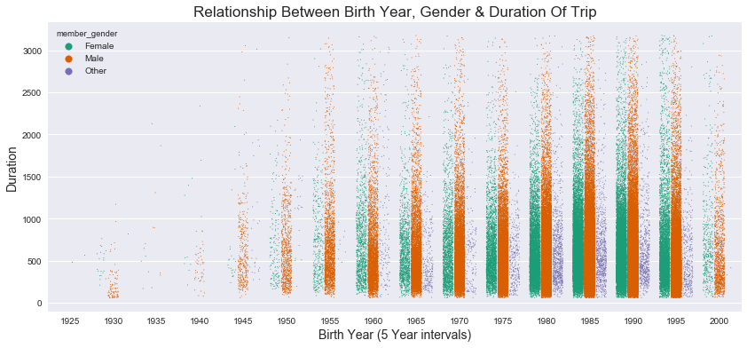

```python
bike_data_clean['member_birth_year_intervals'] = ((bike_data_clean['member_birth_year']//5)*5)

plt.figure(figsize=(14, 6))
sns.stripplot(data=bike_data_clean.query('duration_sec < duration_sec.quantile(0.99) and member_birth_year>1925'),
                                         x='member_birth_year_intervals', y='duration_sec', hue='member_gender',
                                            palette='Dark2', jitter=0.35, dodge=True, size=1)
plt.title('Relationship between birth year, gender & duration of trip'.title(), fontsize=17)
plt.ylabel('Duration', fontsize=14)
plt.xlabel('Birth Year (5 Year intervals)', fontsize=14);
```

### Observation

- We have dense population in the birth year range of 1950 - 1995
- The Male gender dominate the other genders.
- Birth year is slidely proportional to the duration of the ride

```python
bike_data_clean.to_csv('bike clean data.csv', index=False)
```